# Single and Multivariate OLS Regression

2024-08-20

[Handbook Homepage](https://politicalscience.github.io)

## Table of Contents

- Simple Linear Regression (OLS)
- Categorical X Variables
- Multivariate Linear Regression

Remember to load tidyverse

```r
library(tidyverse)
```

Let us also load the dataset we will be using for these examples (feel free to load your own dataset)

```r
df <- read_csv("voctaxdata.csv")
```

Table of Contents | [Handbook Homepage](https://politicalscience.github.io)

# Simple Linear Regression (OLS)

Intuition and Theory | Example in R | Graphing Simple Linear Regression

### Intuition and Theory

A simple linear regression is a method to predict a dependent variable $y$, given a value of an independent variable $x$. Ordinary Least Squares (OLS) is a method to obtain a linear estimation of $y$ given a value of $x$. OLS prediction models take the following form:

$\hat{\mathbf{y}} = \hat{\mathbf{\beta}}_0 + \hat{\mathbf{\beta}}_1 x$

- $\hat{\mathbf{y}}$ is the predicted $y$ from the OLS model
- $x$ is the value of $x$ in which to predict the corresponding $y$
- $\hat{\mathbf{\beta}}_0$ is the intercept coefficient (value of $\hat{\mathbf{y}}$ when $x = 0$)
- $\hat{\mathbf{\beta}}_1$ is the coefficient of $x$ (the amount $\hat{\mathbf{y}}$ increases when $x$ increases by 1)

Note how this is the same form as a standard linear equation: $y=mx+b$ . Our linear regression model will be a straight linear line, as the name implies.

OLS generates an prediction equation in the above form, through selecting $\hat{\mathbf{\beta}}_0$ and $\hat{\mathbf{\beta}}_1$. It selects these coefficient values through finding the coefficient values that minimises the **sum of squared errors** of the prediction model.

- An error is the difference between the actual value of $y$ at a certain $x$ value (let us say $x=i$), and the predicted $\hat{\mathbf{y}}$ of at that same $x$ value produced by the model: $y_i-\hat{\mathbf{y}}_i$
- The squared error is the square of the difference we just calculated: $(y_i-\hat{\mathbf{y_i}})^2$
- The sum of the squared errors is all of the squared errors for every value $i$ of $x$: $\sum (y_i-\hat{\mathbf{y_i}})^2$

OLS methodology uses the following formulas to find the optimal $\hat{\mathbf{\beta}}_0$ and $\hat{\mathbf{\beta}}_1$ that minimises the sum of the squared errors we just described:

- $\hat{\mathbf{\beta}}_1 = \frac{\sum (x_i-\bar x)(y_i - \bar y)}{\sum(x_i-\bar x)^2}$
- $\hat{\mathbf{\beta}}_0 = \bar y - \hat{\mathbf{\beta}}_1 \bar x$

I will not show the mathematical proof of these formulas, as that is beyond what is needed for this lesson. However, a quick google search will show you statistical proofs of the calculations.

For this guide, we will let R do the calculations of coefficients for us, instead of manually plugging in the numbers to these formulas.

Uses of linear regression in Political Science research:

- Linear regression can help establish correlation/covariation between variables, which is essential to establishing causal relationships.
- Linear regression is often used in hypothesis testing to determine if there is a significant relationship between 2 variables, that is not occurring because of chance.

### Example in R

OLS regression in R is conducted using the **lm()** function and **summary()** function. The syntax is as follows:

```r
linear_reg <- lm(Y ~ X, data = df)

# for output, use summary function
summary(linear_reg)
```

These are the parts of the syntax that can be altered:

- **linear_reg** is the variable I am saving my linear regression model to. *You can name this anything you want to.*
- **Y** is the Y variable (Dependent variable) you are trying to predict, and **X** is the X variable (independent variable) you are using to get your prediction. *Replace these with the variables you want to use.*
  - NOTE: Always put the Y variable before the X variable. Separate the two with a tilda **~**
- **df** is the name of the data frame that I am drawing these X and Y variables from. *Replace this with the name of your data frame.*

**Two important notes:**

- If your X variable is categorical/non-continuous/binary, please consult the section: Categorical X Variables
- If your Y variable is categorical/non-continuous/binary, do not use OLS regression. Instead, use [logistic regression](https://politicalscience.github.io/r/logistic.html).

Take the following example, where I am using **econglobal** as my X variable, to predict my Y variable **personal tax**:

```r
linear_reg <- lm(personaltax ~ econglobal, data = df)

#for output, use summary function
summary(linear_reg)
```

```
##
## Call:
## lm(formula = personaltax ~ econglobal, data = df)
##
## Residuals:
##      Min       1Q   Median       3Q      Max
## -21.6794  -3.8740   0.2264   5.8023  26.2537
##
## Coefficients:
##             Estimate Std. Error t value Pr(>|t|)
## (Intercept) -8.23899    5.21677  -1.579    0.116
## econglobal   0.62268    0.06579   9.465   <2e-16 ***
## ---
## Signif. codes:  0 '***' 0.001 '**' 0.01 '*' 0.05 '.' 0.1 ' ' 1
##
## Residual standard error: 8.2 on 253 degrees of freedom
## Multiple R-squared:  0.2615, Adjusted R-squared:  0.2586
## F-statistic: 89.59 on 1 and 253 DF,  p-value: < 2.2e-16
```

The **summary()** function produces an output. The interpretation of the above example is as follows:

- **Intercept Estimate** is the estimated $\hat{\mathbf{\beta}}_0$ (Y-Intercept) of the model. This means, when the X variable (**econglobal** in this case) is equal to 0, there is a predicted -8.2389 value of Y (**personaltax** in this case).
- **econglobal Estimate** is the estimated $\hat{\mathbf{\beta}}_1$ (Slope) of the model. This will be labled whatever your X variable is named. This indicates that for every increase of 1 in the X variable (**econglobal** in this case), there is a predicted 0.62268 increase in the Y variable (**personaltax** in this case).
- **Std. Error** are the standard errors of the estimates of $\hat{\mathbf{\beta}}_0$ and $\hat{\mathbf{\beta}}_1$. Multiply by 1.96, then add and subtract that product from the estimate, to create 95% confidence intervals.
- **Pr(>|t|)** is the P value of the estimate. Basically, if it is less than 0.05, we can generally reject the null hypothesis, and conclude there is a significant relationship.
- The $r^2$ value is the amount of variation in Y explained by the model. In this example, the $r^2$ value shows that our model explains 26.15% of the variation of Y.

### Graphing Simple Linear Regression

We can graph OLS linear regressions with one independent variable in **ggplot**. The syntax is as follows:

```r
df %>%
  ggplot(aes(x = X_variable, y = Y_variable)) +
  geom_point() +
  geom_smooth(method = "lm", color = "red")
```

These are the parts of the syntax that can be altered:

- **df** is the name of the data frame that I am drawing these X and Y variables from. *Replace this with the name of your data frame.*
- **X_variable** is the variable to plot on the X axis, and **Y_variable** is the variable to plot on the Y axis. *Replace these with the variables you want to use.*
- **red** is the colour I am assigning to the best fit line. *You can change this to whatever colour you want (subject to R understanding the colour).*

Take the following example, where I am using **econglobal** as my X variable, to predict my Y variable **personal tax**:

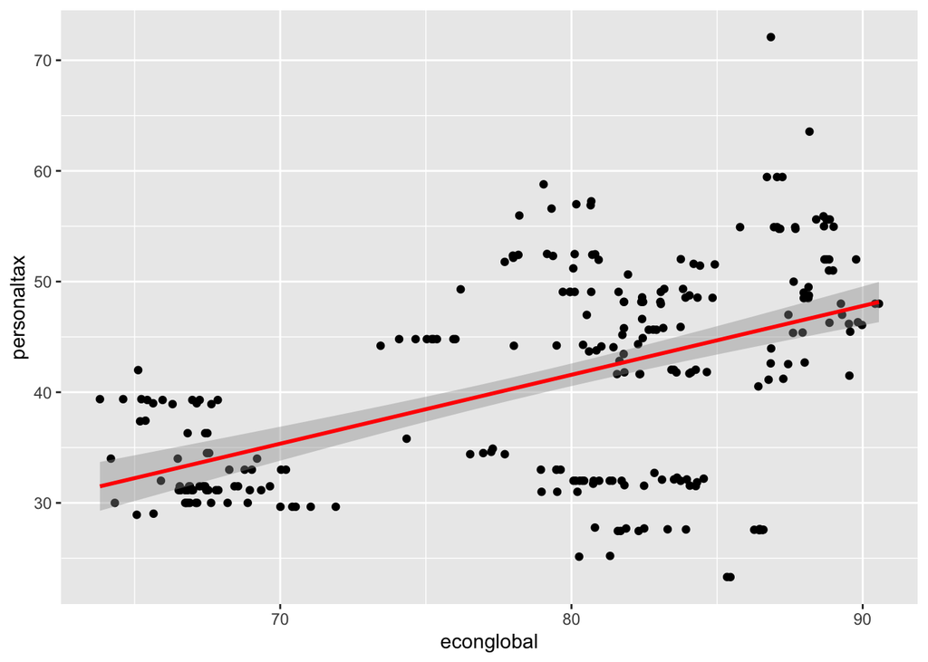

```r
df %>%
  ggplot(aes(x = econglobal, y = personaltax)) +
  geom_point() +
  geom_smooth(method = "lm", color = "red")
```

Table of Contents | [Handbook Homepage](https://politicalscience.github.io)

# Categorical X Variables

Intuition and Theory | Example in R

### Intuition and Theory

Sometimes, we have non-continuous categorical $x$ predictor variables in a regression. These don’t work the same as continuous $x$ variables. Why? Well, it doesn’t really make sense to have a “slope” of $x$ for non-continuous varibales, where one increase of $x$ is associated with a constant increase of $y$.

- For example, if we have the categorical variable **company**, with the vector $<microsoft, apple, google>$, a constant slope makes no sense. Why would an increase of 1 from microsoft to apple, have a constant depedent variable Y change the same as from apple to google? These companies aren’t evenly spaced and ordered on a number line.

Instead, we have to treat these variables as factor variables - comparing each category to each other. For example, let us take the binary categorical X variable **democracy**.

- Our variable democracy (x) has two values:$x = 0$ (not a democracy), and $x = 1$ (democracy)
- Remember our linear regression model: $\hat{\mathbf{y}} = \hat{\mathbf{\beta}}_0 + \hat{\mathbf{\beta}}_1 x$
- Lets insert $x = 0$ and $x = 1$ into the above equation:
  - When $x = 0$ (not a democracy), our equation is: $\hat{\mathbf{y}} = \hat{\mathbf{\beta}}_0$
  - When $x = 1$ (democracy), our equation is: $\hat{\mathbf{y}} = \hat{\mathbf{\beta}}_0 + \hat{\mathbf{\beta}}_1$
- What do we notice? The difference between $x = 0$ (not a democracy) and $x = 1$ (democracy) is $\hat{\mathbf{\beta}}_1$

So, our OLS regression has basically become a **difference-in-means** test! $\hat{\mathbf{\beta}}_1$ is no longer the slope, but the difference between our 2 categories.

What if we have more than 2 categories in our X variable? What we need to do is essentially divide our X variable into X variables with 2 categories (so we can compare the difference!). For example, take the earlier example of the variable **company**, with values $<microsoft, apple, google>$, with values $<0, 1, 2>$

- To make a difference in means test, we can only have binary variables (so we can identify the difference!). So, we have to split this 3-category variable, into 2 variables, each with 2 categories.
- Let us take **microsoft** as our **reference category**. This will be the point of comparison for both our variables.
- Now lets create a variable: **apple or not** ($x_1$). We will define $x_1 = 0$ as **not apple**, and $x_1 = 1$ as **apple**.
- Now lets create a second variable: **google or not** ($x_2$). We will define $x_2 = 0$ as **not google**, and $x_2 = 1$ as **google**.
- We don’t need a variable for our reference category **microsoft**. This is because microsoft is simply when both $x_1, x_2$ are equal to $0$

Now, we will have the following regression equation: $\hat{\mathbf{y}} = \hat{\mathbf{\beta}}_0 + \hat{\mathbf{\beta}}_1 x_1 + \hat{\mathbf{\beta}}_2 x_2$

- To see the prediction for apple, we set $x_1 = 1$, and $x_2 = 0$: $\hat{\mathbf{y}} = \hat{\mathbf{\beta}}_0 + \hat{\mathbf{\beta}}_1$
- To see the prediction for google, we set $x_1 = 0$, and $x_2 = 1$: $\hat{\mathbf{y}} = \hat{\mathbf{\beta}}_0 + \hat{\mathbf{\beta}}_2$
- To see the prediction for microsoft, we set $x_1 = x_2 = 0$: $\hat{\mathbf{y}} = \hat{\mathbf{\beta}}_0$

Thus, the following is true about our coefficients:

- The coefficient of $x_1$, $\hat{\mathbf{\beta}}_1$, is the difference between apple and microsoft (our reference).
- The coefficient of $x_2$, $\hat{\mathbf{\beta}}_2$, is the difference between google and microsoft (our reference).
- The prediction of our reference category, microsoft, is $\hat{\mathbf{\beta}}_0$

The same process works with any X with more than 2 categories. The number of variables to divide X into is $categories - 1$

Uses of Categorical X Variable regression in Political Science:

- Many common variables used in Political Science take the form of categorical variables. For example: democracy or not; type of electoral system; country; etc.

### Example in R

R AUTMOATICALLY DETECTS TEXT-STRING VARIABLES AS FACTOR VARIABLES

- For example, if our variable is {United States, Canada, France}, R will automatically divide the variable into 2 binary variables.
- Thus, if our factor/categorical variables are all text-string type, we don’t have to do any extra work.

HOWEVER, IF THE CATEGORICAL VARIABLE IS ENCODED AS NUMBERS, R DOESN’T KNOW IT IS CATEGORICAL. THUS, WE NEED TO TELL R THIS.

- For example, maybe instead of {United States, Canada, France}, we have a variable {1, 2, 3}, where 1 = US, 2 = Canada, 3 = France. But since the variable is encoded in R as {1, 2, 3}, we have to tell R to treat it like a factor variable.

We can tell R to do this with the **as.factor()** function, and putting that variable we want to treat as a factor inside of it. The syntax is as follows:

```r
as.factor(X) # x is the categorical variable we want to factor
```

We can insert this **as.factor()** function into anywhere where there is a variable in R. For example, let us do a regression, where we predict **personaltax** using the factored variable **voc**. R will automatically treat either $x = 0$ or the first category of the variable vector as the reference category.

```r
factor_linear_reg <- lm(personaltax ~ as.factor(voc), data = df)

#for output, use summary function
summary(factor_linear_reg)
```

```
##
## Call:
## lm(formula = personaltax ~ as.factor(voc), data = df)
##
## Residuals:
##     Min      1Q  Median      3Q     Max
## -21.016  -4.629  -0.174   4.755  27.782
##
## Coefficients:
##                 Estimate Std. Error t value Pr(>|t|)
## (Intercept)      35.7786     0.8485  42.168  < 2e-16 ***
## as.factor(voc)1   8.5324     1.0954   7.789 1.74e-13 ***
## ---
## Signif. codes:  0 '***' 0.001 '**' 0.01 '*' 0.05 '.' 0.1 ' ' 1
##
## Residual standard error: 8.569 on 253 degrees of freedom
## Multiple R-squared:  0.1934, Adjusted R-squared:  0.1902
## F-statistic: 60.68 on 1 and 253 DF,  p-value: 1.737e-13
```

The coefficient that has been produced is the difference in means. If you have more categories, R will display more coefficients (remember, number of categories - 1).

Table of Contents | [Handbook Homepage](https://politicalscience.github.io)

# Multivariate Linear Regression

Intuition and Theory | Example in R

### Intuition and Theory

Almost always in political science (and the social sciences), we will need more than one X predictor variable. This is because the world is very complicated, and rarely does one variable explain everything.

Multivariate regression takes the following form: $\hat{\mathbf{y}} = \hat{\mathbf{\beta}}_0 + \hat{\mathbf{\beta}}_1 x_1 + \hat{\mathbf{\beta}}_2 x_2 + ... + \hat{\mathbf{\beta}}_p x_p$

- Where each $x_1, x_2, ... , x_p$ is a different independent variable.

You can include as many $x$ variables as the amount of observations you have. Although, generally, the closer the number of X variables is to your number of observations, the less explanatory the model will be. You can include any type of variable, including both continuous and categorical variables.

- Remember to use **as.factor()** on categorical variables when applicable (see section: Factor X Variables (Non-Continuous X Variables))

The great thing about multivariate linear regression is that each $\hat{\mathbf{\beta}}_p x_p$ is added together (see equation above). This allows for one key thing: **we can hold other variables constant to see the effect of one X variable on Y**.

- $\hat{\mathbf{\beta}}_p$ is the effect on $x_p$ on $y$, given all other $x_1, x_2, ...$ are held constant.

Uses of multivariate linear regression in Political Science research:

- Since we can hold other variables constant, this allows us to focus on the effect of one independent variable, and treat the others as control variables. Controlling for alternative explanations is a key part in determining causality.
- Political Science phenomena are rarely caused by just one variable. Thus, to make accurate predictions, multivariate linear regression is very useful, as it allows us to include many different potential causes and factors.

### Example in R

The syntax for multiple linear regression is very similar to that of simple linear regression. We simply add additional x variables behind the 1st X variable with **+** signs.

```r
multiple_reg <- lm(Y ~ X1 + X2 + X3 + X4, data = df)

#for output, use summary function
summary(multiple_reg)
```

These are the parts of the syntax that can be altered:

- **multiple_reg** is the variable I am saving my linear regression model to. *You can name this anything you want to.*
- **Y** is the Y variable (Dependent variable) you are trying to predict, and **X1, X2, X3…** are the X variables (independent variables) you are using to get your prediction. *Replace these with the variables you want to use.*
  - NOTE: Always put the Y variable before the X variable. Separate the two with a tilda **~**
  - NOTE: You can add more simply by using a **+** sign and adding another variable.
- **df** is the name of the data frame that I am drawing these X and Y variables from. *Replace this with the name of your data frame.*

If you want to include a ton of X variables (For example, all other variables in your dataset), you can also use the following syntax:

```r
multiple_reg <- lm(Y ~ ., data = df)

#for output, use summary function
summary(multiple_reg)
```

These are the parts of the syntax that can be altered:

- **multiple_reg** is the variable I am saving my linear regression model to. *You can name this anything you want to.*
- **Y** is the Y variable (Dependent variable) you are trying to predict
- The period “**.**” tells R to include all other variables in the data frame as independent variables.
  - NOTE: Please check that you genuinely want all variables in the data frame in your regression. Sometimes, variables (such as ID) make no sense to include. If you need to exclude any, you can use the **select()** function introduced in the Visualizing Data lesson.
- **df** is the name of the data frame that I am drawing these X and Y variables from. *Replace this with the name of your data frame.*

Take this example of predicting the Y variable **personaltax** with the X variables **econglobal** and **socialexp**:

```r
multiple_reg <- lm(personaltax ~ econglobal + socialexp, data = df)

#for output, use summary function
summary(multiple_reg)
```

```
##
## Call:
## lm(formula = personaltax ~ econglobal + socialexp, data = df)
##
## Residuals:
##      Min       1Q   Median       3Q      Max
## -16.6821  -6.0305   0.1867   5.7024  30.0412
##
## Coefficients:
##              Estimate Std. Error t value Pr(>|t|)
## (Intercept) -12.62637    4.87775  -2.589   0.0102 *
## econglobal    0.48738    0.06433   7.576 6.79e-13 ***
## socialexp     0.68117    0.10394   6.553 3.15e-10 ***
## ---
## Signif. codes:  0 '***' 0.001 '**' 0.01 '*' 0.05 '.' 0.1 ' ' 1
##
## Residual standard error: 7.594 on 252 degrees of freedom
## Multiple R-squared:  0.369,  Adjusted R-squared:  0.364
## F-statistic: 73.69 on 2 and 252 DF,  p-value: < 2.2e-16
```

Interpretation is the same as Single Linear Regression, except that we have an extra variable. When interpreting one variable, always mention that the other variables are **being held constant**.

Take this second example of prediction the Y variable **personaltax** with every other variable in the data frame **df** acting as an X variable:

```r
multiple_reg_2 <- lm(personaltax ~ ., data = df)
summary(multiple_reg_2)
```

```
##
## Call:
## lm(formula = personaltax ~ ., data = df)
##
## Residuals:
##     Min      1Q  Median      3Q     Max
## -9.4534 -1.7716 -0.0555  1.2378 24.8743
##
## Coefficients: (17 not defined because of singularities)
##                         Estimate Std. Error t value Pr(>|t|)
## (Intercept)             23.12688   16.39167   1.411 0.159610
## id                      -0.13342    0.07940  -1.680 0.094244 .
## countryid                3.96406    1.52821   2.594 0.010090 *
## countrynameaustria     -12.36208    5.62004  -2.200 0.028815 *
## countrynamebelgium     -15.58986    7.10656  -2.194 0.029243 *
## countrynamecanada      -10.01885    1.70580  -5.873 1.46e-08 ***
## countrynamedenmark     -24.76300    7.03547  -3.520 0.000519 ***
## countrynamefinland     -19.64669    6.70707  -2.929 0.003735 **
## countrynamegermany      -9.82812    5.85264  -1.679 0.094441 .
## countrynameireland       2.04381    6.74276   0.303 0.762076
## countrynamenetherlands -22.23830    7.78646  -2.856 0.004677 **
## countrynamenewzealand  -12.89300    2.09127  -6.165 3.08e-09 ***
## countrynamenorway      -27.79512    7.38371  -3.764 0.000211 ***
## countrynamesweden      -36.51275    8.31236  -4.393 1.70e-05 ***
## countrynameswitzerland -34.56724    7.68704  -4.497 1.09e-05 ***
## countrynameuk          -11.17182    3.41559  -3.271 0.001235 **
## countrynameusa                NA         NA      NA       NA
## countrycodeaut                NA         NA      NA       NA
## countrycodebel                NA         NA      NA       NA
## countrycodecan                NA         NA      NA       NA
## countrycodeche                NA         NA      NA       NA
## countrycodedeu                NA         NA      NA       NA
## countrycodednk                NA         NA      NA       NA
## countrycodefin                NA         NA      NA       NA
## countrycodegbr                NA         NA      NA       NA
## countrycodeirl                NA         NA      NA       NA
## countrycodenld                NA         NA      NA       NA
## countrycodenor                NA         NA      NA       NA
## countrycodenzl                NA         NA      NA       NA
## countrycodeswe                NA         NA      NA       NA
## countrycodeusa                NA         NA      NA       NA
## year                          NA         NA      NA       NA
## voc                           NA         NA      NA       NA
## taxpercent               0.60707    0.16910   3.590 0.000403 ***
## corporatetax             0.26688    0.11293   2.363 0.018941 *
## econglobal              -0.08931    0.19406  -0.460 0.645794
## gini                    -0.57088    0.24473  -2.333 0.020518 *
## socialexp                0.25959    0.13876   1.871 0.062616 .
## export                   0.19458    0.05110   3.808 0.000179 ***
## ---
## Signif. codes:  0 '***' 0.001 '**' 0.01 '*' 0.05 '.' 0.1 ' ' 1
##
## Residual standard error: 3.553 on 233 degrees of freedom
## Multiple R-squared:  0.8723, Adjusted R-squared:  0.8608
## F-statistic: 75.77 on 21 and 233 DF,  p-value: < 2.2e-16
```

Table of Contents | [Handbook Homepage](https://politicalscience.github.io)

## Linear Regression with Moderating/Interaction Effects

The Multiple Linear Regression we looked at before assumes that each variable has an independent effect. That means, one variable’s impact on Y does not affect another variable’s impact on Y.

However, this isn’t always the case. There are plenty of times where one variable’s value will impact the strength the the relationship between another variable and Y.

- For example, there is a relationship between high speeds and accident frequency in cars. However, this relationship because far more dangerous if the roads are slippery. So, the slippery roads is **moderating/interacting with** the effect between high speeds and accident frequency.

We can implement moderating/interaction effects in R with the * sign, where * goes between the two X variables that affect each other (**Y ~ X1 * X2 + X3 + X4…**). In the example below:

```r
moderating_reg <- lm(personaltax ~ econglobal*as.factor(voc) + socialexp, data = df)

#for output, use summary function
summary(moderating_reg)
```

```
##
## Call:
## lm(formula = personaltax ~ econglobal * as.factor(voc) + socialexp,
##     data = df)
##
## Residuals:
##      Min       1Q   Median       3Q      Max
## -16.5460  -5.8385   0.4085   5.4778  30.4030
##
## Coefficients:
##                             Estimate Std. Error t value Pr(>|t|)
## (Intercept)                -14.53102    6.76833  -2.147   0.0328 *
## econglobal                   0.51804    0.08803   5.885 1.27e-08 ***
## as.factor(voc)1             13.34704   15.07348   0.885   0.3768
## socialexp                    0.66021    0.11887   5.554 7.13e-08 ***
## econglobal:as.factor(voc)1  -0.16220    0.18526  -0.876   0.3821
## ---
## Signif. codes:  0 '***' 0.001 '**' 0.01 '*' 0.05 '.' 0.1 ' ' 1
##
## Residual standard error: 7.613 on 250 degrees of freedom
## Multiple R-squared:  0.371,  Adjusted R-squared:  0.361
## F-statistic: 36.87 on 4 and 250 DF,  p-value: < 2.2e-16
```

Interpretation of this is a little different:

- **Intercept** is the same as the other OLS models we have covered. Still means value of Y when all others are equal to 0.
- **econglobal** is the effect of X1 (**econglobal**) on Y (**personaltax**), when the other interacting variable X2 (**voc**) is equal to 0.
- **econglobal:as.factor(voc)1** is the moderating term. This shows the difference of the effect of X1 (**econglobal**) on Y between when **voc** is 0 and 1.
- Naturally then, we can deduce that **econglobal + econglobal:as.factor(voc)1** is the effect of X1 (**econglobal**) on Y (**personaltax**), when the other interacting variable X2 (**voc**) is equal to 1.
- **socialexp** is the same as other OLS models, a standard control assuming everything else is held constant.

If the moderating term (**econglobal:as.factor(voc)1**) is statistically significant, then we can conclude that there is a significant interaction between the two interacting variables. If this isn’t significant, then there is no interaction, and you probably don’t need to include the interaction effect.

Table of Contents | [Handbook Homepage](https://politicalscience.github.io)